# Analyse des trajectoires types des carrières des agriculteurs comparativement à la population générale

Coraline Best, Léo Quennesson, Clément Rousset

2024-05-14

# Objectifs de l’étude

Cette étude vise à détailler les évolutions des carrières des agriculteurs sur une période de 5 ans. Ces évolutions seront comparées aux évolutions de la population générale.

Ces transitions peuvent être analysées au travers du prisme de l’âge des individus, mais également du type d’emploi occupé et des grands événements de la vie (naissance d’un enfant, études et formation, retraite).

Si l’on considère l’âge de l’individu, les transitions professionnelles peuvent être analysées :

- Avant leur vie professionnelle, les individus participent pas ou peu au marché du travail afin **d’étudier**;
- Par la suite, les individus participent au marché du travail, cherchant un **emploi** qui correspond à leurs qualifications et à leurs intérêts.
- Enfin en fin de carrière, les individus quittent leur emploi pour bénéficier de leur **retraite**.

Pendant les périodes de participation au marché du travail, de nombreux évènements peuvent interrompre ou mettre **fin à un contrat**. Que ce soit un licenciement ou un changement de poste, un arrêt maladie ou de formation, un congé sabatique, ces changements de situation viennent modifier le revenu des individus.

Ces changements de situation, de nature diverse, touchent inégalement les individus. A titre illustratif, il est possible de ventiler le marché du travail entre des emplois à temps plein et partiel. On peut ainsi se demander si ces deux formes d’emplois sont complémentaires dans la vie d’un individu. Ces transitions font partie intégrante de la vie professionnelle : afin de répondre à ces questions, l’étude doit nécessairement prendre en compte les facteurs personnels, économiques ou encore sociaux des individus.

**L’objectif de cette étude est de dresser un portrait robot des principales transitions rencontrées dans la vie des individus au cours de leur vie professionnelle**.

L’objectivation et la quantification de ces transitions serviront dans une seconde phase à la DREES à affiner les simulations des transitions professionnelles par population concernée.

Les variations de salaire liées à ces transitions professionnelles sont à mettre en regard avec un ensemble de mécanisme visant à limiter et à lisser dans le temps les pertes de revenus. En effet prestations sociales - et en premier lieu le RSA, la prime d’activité, l’allocation de solidarité spécifique et les allocations logement - mais aussi les cotisations et impôts, participent au lissage du revenu des individus pendant ces périodes de transition.

**Cette étude permettra donc infine de souligner la cohérence et l’efficacité du système sociofiscal au périodes de transition professionnelle et, le cas échéant, visera à proposer des réformes pertinentes.**

# Conception de la base

On constitue une première base avec les informations individuelles, notamment le sexe et la date de naissance, en se restraignant d’une part aux agriculteurs et d’autres part à 10000 individus selectionnés au hasard dans la population générale.

On ajoute à ces individus les salaires mensuels percus (montant net versé) : les lignes sont en conséquence dupliquées 60 fois (12 mois sur 5 ans) pour chaque individus.

Enfin sur cette base cylindrée on ajoute les informations existantes portant sur : - la nature du contrat (CDI, CDD); - la quotité horaire travaillée : temps plein ou partiel ; - secteur : agriculteur, artisan … (10 modalités); - raison de rupture : licenciements, ruptures, fin de contrat ; - CPS.

# Statisques descriptives

Les informations individuelles se présentent sous la forme suivante.

```
##    id_assure annee  mois statut
##        <i64> <int> <int> <char>
## 1:       102  2019     1 absent
## 2:       102  2019     2 absent
## 3:       102  2019     3 absent
## 4:       102  2019     4 absent
## 5:       102  2019     5 absent
## 6:       102  2019     6 absent
```

**Au sein de la population générale, dans 6 cas sur 10, l’individu connait une interruption d’activité (chômage , ASS etc).**

Population générale

| Statut | Nombre de mois | Pourcentage |
| --- | --- | --- |
| absent | 302321 | 61.22 |
| temps plein | 74661 | 15.12 |
| temps partiel | 66465 | 13.46 |
| arret maladie | 37599 | 7.61 |
| autre arret | 8667 | 1.75 |
| Congé maternité/paternité | 4147 | 0.84 |

**Les agriculteurs connaissent davantage d’interruption que la population générale.**

Agriculteurs

| Statut | Nombre de mois | Pourcentage |
| --- | --- | --- |
| absent | 138390 | 86.65 |
| temps plein | 11782 | 7.38 |
| temps partiel | 8097 | 5.07 |
| arret maladie | 1195 | 0.75 |
| autre arret | 245 | 0.15 |
| Congé maternité/paternité | 11 | 0.01 |

L’objectif est d’analyser ces interruptions d’activité.

Afin de renforcer la fiabilité des données, on ne garde que les données entre 2021 et mai 2023. On observe en effet beaucoup de données manquantes avant cette période.

# Méthodologie de l’analyse de séquences

La méthodologie est fortement inspirée de l’analyse de Nicolas Robette intitulé L’analyse de séquences : une introduction avec le logiciel R et le package TraMineR et publié sur le blog Quanti (http://quanti.hypotheses.org/686/).

Sous R, le package TraMineR fournit une solution complète : on y trouve l’appariement optimal mais aussi d’autres algorithmes alternatifs, ainsi que de nombreuses fonctions de description des séquences et de représentation graphique.

L’appariement optimal consiste, pour chaque paire de séquences, à compter le nombre minimal de modifications (substitutions, suppressions, insertions) qu’il faut faire subir à l’une des séquences pour obtenir l’autre.

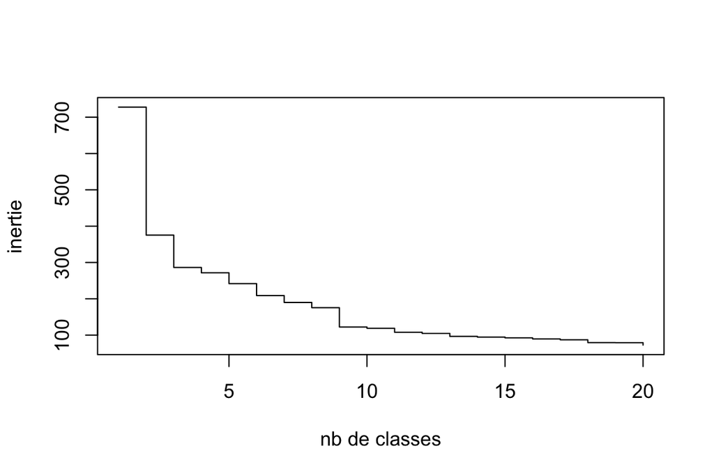

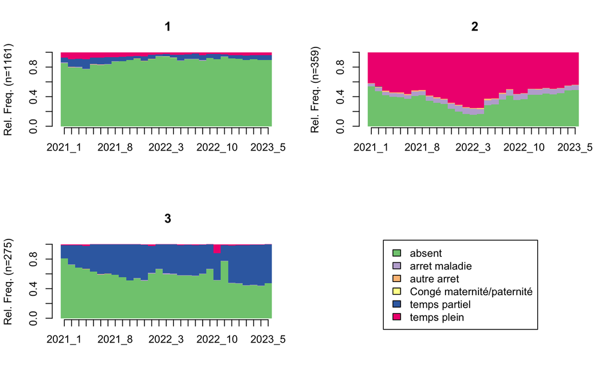

Part des hommes et des femmes agriculteurs dans les clusters modélisés

|  | F | H | Ensemble |
| --- | --- | --- | --- |
| 1 | 62 | 68 | 64 |
| 2 | 21 | 20 | 20 |
| 3 | 17 | 12 | 15 |
| Total | 100 | 100 | 100 |

# Principaux résultats et pistes d’amélioration

**Pistes d’amélioration :**

- Généralisation à l’ensemble des PCS
- Chiffrage de la perte monétaire liée à la période d’interruption
- Rôle contracyclique du système de protection social pouvant mener à des pistes de réformes pour les populations les plus fragiles.